# Group Project - Global Seafood 96705

DSA2101 Project

2024-04-19

```r
# Load Data
farmed <- readr::read_csv('https://raw.githubusercontent.com/rfordatascience/tidytuesday/master/data/2021/2021-10-12/aquaculture-farmed-fish-production.csv')
captured_vs_farmed <- readr::read_csv('https://raw.githubusercontent.com/rfordatascience/tidytuesday/master/data/2021/2021-10-12/capture-fisheries-vs-aquaculture.csv')
captured <- readr::read_csv('https://raw.githubusercontent.com/rfordatascience/tidytuesday/master/data/2021/2021-10-12/capture-fishery-production.csv')
consumption <- readr::read_csv('https://raw.githubusercontent.com/rfordatascience/tidytuesday/master/data/2021/2021-10-12/fish-and-seafood-consumption-per-capita.csv')
stock <- readr::read_csv('https://raw.githubusercontent.com/rfordatascience/tidytuesday/master/data/2021/2021-10-12/fish-stocks-within-sustainable-levels.csv')
fishery <- readr::read_csv('https://raw.githubusercontent.com/rfordatascience/tidytuesday/master/data/2021/2021-10-12/global-fishery-catch-by-sector.csv')
production <- readr::read_csv('https://raw.githubusercontent.com/rfordatascience/tidytuesday/master/data/2021/2021-10-12/seafood-and-fish-production-thousand-tonnes.csv')
```

```r
# Installing packages if not installed yet

packages = c('lubridate', 'stringr', 'ggplot2', 'tidyverse', 'maps', 'showtext', 'countrycode', 'biscale', 'cowplot', 'scales', 'shadowtext', 'ggrepel')

install_load <- function(packages){
     for (p in packages) {
          if (p %in% rownames(installed.packages())) {
               library(p, character.only=TRUE)
          } else {
               install.packages(p)
               library(p,character.only = TRUE)
          }
     }
}

install_load(packages)

showtext_opts(dpi = 320)
showtext_auto(enable = TRUE)
```

# 1 Introduction

More than one-third of the world’s population rely on fish as a mainstay in their diet, as it is seemingly the cheapest source of protein globally (*Tidwell & Allan*, 2001). This has led to a drastic increase in fishing and the boom in fish farming. But as demand rises faster than supply can regenerate, fisheries are now over-exploited and depleted, with only 10% of worldwide stocks left (*The World Counts*, n.d.). The urgency is not lost on us, along with many organisations who are racing to find solutions to mitigate this issue, but without much success.

Completely stopping the whole world from consuming seafood is not possible, so instead, we should focus our efforts on making fishing more sustainable. There are two types of fishing - wild catching, and fish farming, also known as aquaculture. The mass fishing of wild fishes is considered more unsustainable, as it impacts the biodiversity of the ocean (*McKeever*, 2022), and places stress an wild fish populations. Aquaculture provides a controlled farming environment and is hence the more sustainable option.

With this background knowledge and the datasets in hand, we explore our research question : Considering current trends in sustainable fishing, consumption, and species production, what conclusions can we make for global fishery sustainability and food security?

# 2 Plot 1

## 2.1 Data cleaning for Plot 1

```r
# Pivot the stock data longer
stocks <- stock %>% filter(Code=='OWID_WRL') %>%
  pivot_longer(cols=-c(Entity, Code, Year)) %>%
  mutate(value2 = ifelse(
    name=="Share of fish stocks within biologically sustainable levels (FAO, 2020)",-1*value, value))

# Find the percentage of stock in the earliest (1978) and latest year (2017)
overexp_1978 <- stocks %>% filter(Year=='1978',
                  name== 'Share of fish stocks that are overexploited') %>% .$value
overexp_2017 <- stocks %>% filter(Year=='2017',
                  name== 'Share of fish stocks that are overexploited') %>% .$value
```

## 2.2 Bar plot of Fish stock over the Years

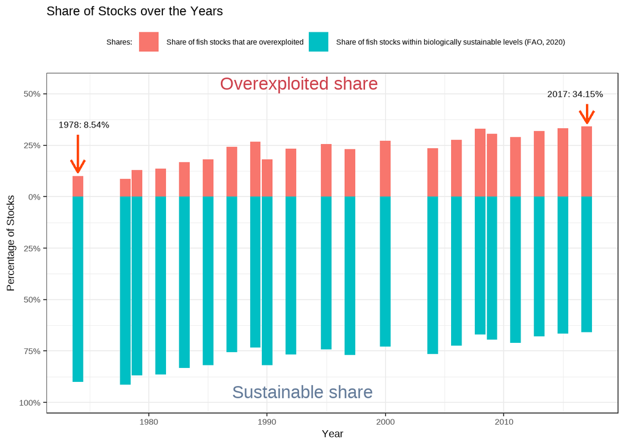

```r
stocks %>% ggplot() +
  geom_col(aes(x=Year, y=value2/100, fill=name)) +
  labs(title="Share of Stocks over the Years",
       y="Percentage of Stocks", x="Year",
       fill = 'Shares:') +
  annotate(geom="text",x=1987, y = -.95, label=("Sustainable share"),
           color="#3d5a80", size = 3, alpha=.8,hjust=0) +
  annotate(geom="text",x=1986, y =.55, label=("Overexploited share"),
           color="#c1121f", size =3, alpha=.8,hjust=0) +
  scale_y_continuous(limits = c(-1,.55), expand=c(0.02,0.02),
                     breaks = seq(-1,.5,0.25),
                     labels = c("100%", "75%", "50%","25%", "0%","25%","50%"),
                     position="left") +
  annotate(geom='text', size = 1.5, x = 1974.5, y =.35,
           label=str_interp("1978: $[.2f]{overexp_1978}%")) +
  annotate("segment", x = 1974, y = .30, xend = 1974,
           yend = .12, color = "#FF4500", size = 1,
           arrow=arrow(length=unit(4, "mm"))) +
  annotate(geom='text', size = 1.5, x = 2016, y =.50,
           label=str_interp("2017: $[.2f]{overexp_2017}%")) +
  annotate("segment", x = 2017, y = .45, xend = 2017,
           yend = .36, color = "#FF4500", size = 1,
           arrow=arrow(length=unit(4, "mm"))) +
  theme_bw() +
  theme(legend.title = element_text(size = 3.5),
        legend.text = element_text(size = 3.5),
        legend.position="top",
        text= element_text(size=5))
```

# 3 Plot 2

## 3.1 Data cleaning for Plot 2

```r
# Cleaning production data set
df_prod = production %>%
  filter(!Code %in% c("OWID_WRL", "OWID_USS"), !is.na(Code)) %>%
  pivot_longer(cols = -c(Entity, Code, Year)) %>%
  mutate(Fish = str_split(name, " - ", simplify = TRUE)[,3],
         Fish = str_remove(Fish, ". Other")) %>%
  group_by(Entity, Code, Year) %>%
  summarise(total = sum(value, na.rm = TRUE))

# Cleaning consumption data set
df_consume = consumption %>%
  filter(Code %in% df_prod$Code, Year %in% df_prod$Year) %>%
  mutate(Consumption = `Fish, Seafood- Food supply quantity (kg/capita/yr) (FAO, 2020)`)

# Top 5 countries in consumption
top5_consume = df_consume %>%
  group_by(Entity, Code) %>%
  summarise(total = sum(Consumption)) %>%
  ungroup() %>%
  slice_max(total, n = 5)

# getting production for top 5 consumption ctry
selected_prod = df_prod %>%
  filter(Entity %in% top5_consume$Entity)

# getting consumption for top 5 consumption ctry
selected_consume = df_consume %>%
  filter(Entity %in% top5_consume$Entity) %>%
  mutate(Entity = factor(Entity, levels =top5_consume$Entity))
```

## 3.2 Line plot of Consumption over time

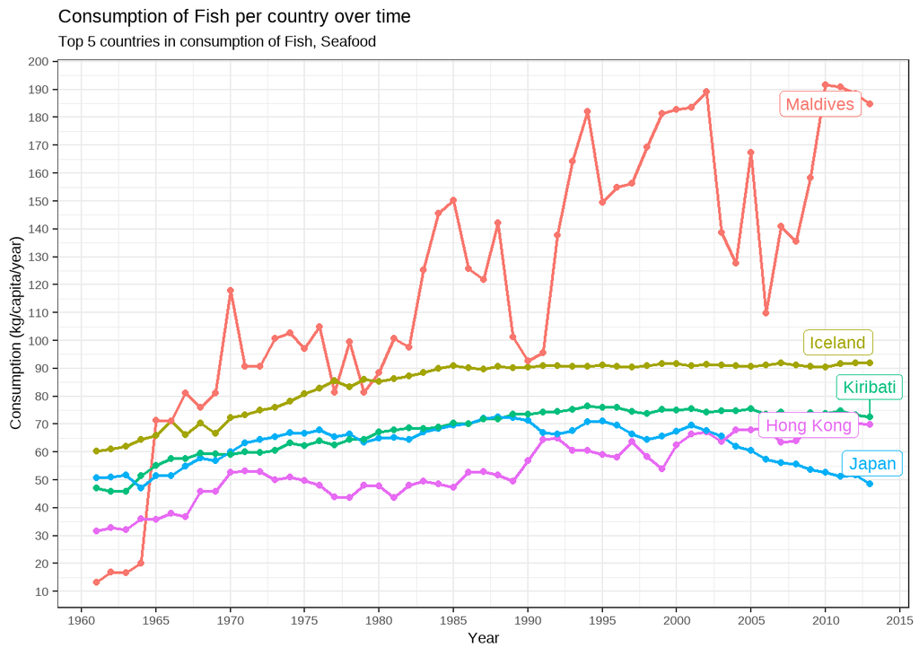

```r
ggplot(data = selected_consume,
       aes(x = Year, y = Consumption, color = Entity)) +
  geom_line(lwd = 0.8) +
  geom_point(size= 1.5)  +
  geom_label_repel(data=selected_consume %>% filter(Year=='2013'),
             aes(x = Year,y = Consumption, label = Entity),
             size = 2, check_overlap = TRUE) +
  labs(x = "Year", y = "Consumption (kg/capita/year)",
       title = "Consumption of Fish per country over time",
       subtitle = "Top 5 countries in consumption of Fish, Seafood") +
  scale_x_continuous(breaks = round(seq(min(1960), max(2015), by = 5),1)) +
  scale_y_continuous(breaks = round(seq(0, 200, by = 10),1)) +
  theme_bw() +
  theme(legend.title = element_text(size = 3.5),
        legend.text = element_text(size = 3.5),
        text= element_text(size=5),
        legend.position="none")
```

## 3.3 Plot 2 Analysis

From the graph above, we can observe that the Maldives has the highest consumption of seafood per capita, followed by Iceland, Kiribati, Japan and the others. This reveals some important information pertaining to the geographical context of these countries, which we will explore further in the discussion. While consumption levels are important, this is not indicative of their levels of sustainability and we hence need to explore the levels of sustainability in these countries, by observing proportion of wild capture to aquaculture.

# 4 Plot 3

## 4.1 Data cleaning for Plot 3

```r
#Obtaining Country Data from maps
captured_data <- captured_vs_farmed %>%
  filter(Year == "2018") %>%
  rename('Aquaculture_production'
         = 'Aquaculture production (metric tons)',
         'Capture_fisheries_production'
         = 'Capture fisheries production (metric tons)')

# Add Bivariate map for countries
cap_dat_bi <- captured_data%>% group_by(Entity)  %>%
  summarize(Aquaculture_production
            = median(Aquaculture_production),
            Capture_fisheries_production
            = median(Capture_fisheries_production)) %>%
  mutate(Aquaculture_production
         = ifelse(is.na(Aquaculture_production), 0,
                  Aquaculture_production),
         Capture_fisheries_production
         = ifelse(is.na(Capture_fisheries_production), 0,
                  Capture_fisheries_production)) %>%
  bi_class(y = Aquaculture_production, x = Capture_fisheries_production,
           style = "quantile", dim = 3)

# Find the top 3 countries for Aquaculture and Farm Fisheries
captured_data_clean = captured_data %>%
  filter(!is.na(Code))

top_aqua = captured_data_clean %>%
  arrange(desc(Aquaculture_production)) %>%
  slice_max(n=3, order_by = c(`Aquaculture_production`))

top_cult = captured_data_clean %>%
  arrange(desc(Capture_fisheries_production)) %>%
  slice_max(n=3, order_by = c(`Capture_fisheries_production`))
```

Some countries are not properly named or have various naming formats and thus we would need to re-code these names manually.

```r
cap_dat_bi$Entity <- recode(cap_dat_bi$Entity, "United Kingdom" = "UK")
cap_dat_bi$Entity <- recode(cap_dat_bi$Entity, "United States" = "USA")
cap_dat_bi$Entity <- recode(cap_dat_bi$Entity, "Russian Federation" = "Russia")
cap_dat_bi$Entity <- recode(cap_dat_bi$Entity, "Antigua and Barbuda" = "Antigua")
cap_dat_bi$Entity <- recode(cap_dat_bi$Entity, "Bahamas, The" = "Bahamas")
cap_dat_bi$Entity <- recode(cap_dat_bi$Entity, "Cabo Verde" = "Cape Verde")
cap_dat_bi$Entity <- recode(cap_dat_bi$Entity, "Congo, Dem. Rep." = "Democratic Republic of the Congo")
cap_dat_bi$Entity <- recode(cap_dat_bi$Entity, "Egypt, Arab Rep." = "Egypt")
cap_dat_bi$Entity <- recode(cap_dat_bi$Entity, "Gambia, The" = "Gambia")
cap_dat_bi$Entity <- recode(cap_dat_bi$Entity, "Iran, Islamic Rep." = "Iran")
cap_dat_bi$Entity <- recode(cap_dat_bi$Entity, "Kyrgyz Republic" = "Kyrgyzstan")
cap_dat_bi$Entity <- recode(cap_dat_bi$Entity, "Lao PDR" = "Laos")
cap_dat_bi$Entity <- recode(cap_dat_bi$Entity, "Micronesia, Fed. Sts." = "Micronesia")
cap_dat_bi$Entity <- recode(cap_dat_bi$Entity, "Sint Maarten (Dutch part)" = "Sint Maarten")
cap_dat_bi$Entity <- recode(cap_dat_bi$Entity, "Slovak Republic" = "Slovakia")
cap_dat_bi$Entity <- recode(cap_dat_bi$Entity, "Syrian Arab Republic" = "Syria")
cap_dat_bi$Entity <- recode(cap_dat_bi$Entity, "Trinidad and Tobago" = "Trinidad")
cap_dat_bi$Entity <- recode(cap_dat_bi$Entity, "Venezuela, RB" = "Venezuela")
cap_dat_bi$Entity <- recode(cap_dat_bi$Entity, "Virgin Islands (U.S.)" = "Virgin Islands")
cap_dat_bi$Entity <- recode(cap_dat_bi$Entity, "Yemen, Rep." = "Yemen")
cap_dat_bi$Entity <- recode(cap_dat_bi$Entity, "Korea, Dem. People's Rep." = "North Korea")
cap_dat_bi$Entity <- recode(cap_dat_bi$Entity, "Korea, Rep." = "South Korea")
cap_dat_bi$Entity <- recode(cap_dat_bi$Entity, "North Macedonia" = "Macedonia")
cap_dat_bi$Entity <- recode(cap_dat_bi$Entity, "Brunei Darussalam" = "Brunei")
cap_dat_bi$Entity <- recode(cap_dat_bi$Entity, "Cote d'Ivoire" = "Ivory Coast")
cap_dat_bi$Entity <- recode(cap_dat_bi$Entity, "Micronesia, Fed. Sts." = "Micronesia")
cap_dat_bi$Entity <- recode(cap_dat_bi$Entity, "Yemen, Rep." = "Yemen")
cap_dat_bi$Entity <- recode(cap_dat_bi$Entity, "Democratic Republic of Congo" = "Democratic Republic of the Congo")
cap_dat_bi$Entity <- recode(cap_dat_bi$Entity, "Micronesia (country)" = "Micronesia")
cap_dat_bi$Entity <- recode(cap_dat_bi$Entity, "Saint Vincent and the Grenadines" = "Saint Vincent")
cap_dat_bi$Entity <- recode(cap_dat_bi$Entity, "Timor" = "Timor-Leste")
cap_dat_bi$Entity <- recode(cap_dat_bi$Entity, "Congo" = "Republic of Congo")
cap_dat_bi$Entity <- recode(cap_dat_bi$Entity, "Saint Kitts and Nevis" = "Saint Kitts")
cap_dat_bi$Entity <- recode(cap_dat_bi$Entity, "Czechia" = "Czech Republic")
```

```r
world <- map_data("world") %>%
  filter(region != "Antarctica")

world_dat_bi <-  cap_dat_bi %>%
  left_join(world, by = c('Entity'='region'))

top_3_map <- world_dat_bi %>%
  filter(Entity %in% c(top_aqua$Entity, top_cult$Entity))
```

## 4.2 Map plot of Aquaculture and Capture Fisheries Production in 2018

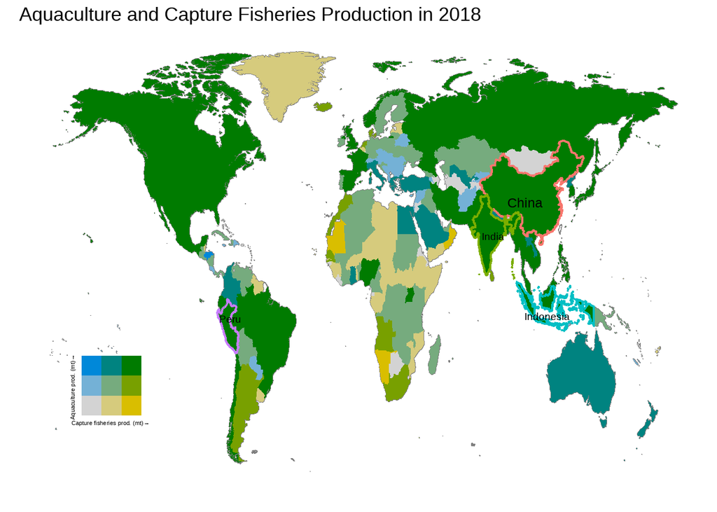

```r
world_plot <- ggplot() +
  geom_map(data = world, map = world,
           aes(long, lat, group = group,  map_id = region),
           fill = "white", color = "grey50") +
  geom_map(data = world_dat_bi, map = world,
           aes(fill = bi_class, map_id = Entity)) +
  geom_map(data = top_3_map, map = world,
           aes(map_id = Entity, color = Entity), fill=NA, size=0.8) +

  bi_scale_fill(pal = "BlueYl", dim = 3, guide = "none") +

  labs(title="Aquaculture and Capture Fisheries Production in 2018",
       x = element_blank(), y=element_blank(),
       color='Top Countries') +

  theme(plot.title = element_text(size = 8),
    panel.background = element_rect(fill = "white"),
    panel.grid = element_blank(),
    legend.position = 'none',
    axis.ticks = element_blank(),
    axis.text = element_blank()) +

  annotate("text", x = 90, y = 31,
           label = "China",
           hjust = 0, vjust = 0, size = 2) +
  annotate("text", x = 100, y = -7,
           label = "Indonesia",
           hjust = 0, vjust = 0, size = 1.5) +
  annotate("text", x = 75, y = 20,
           label = "India",
           hjust = 0, vjust = 0, size = 1.5) +
  annotate("text", x = -80, y = -8,
           label = "Peru",
           hjust = 0, vjust = 0, size = 1.5)

fish_grid <- bi_legend(pal = "BlueYl",
  dim = 3,
  xlab = "Capture fisheries prod. (mt)",
  ylab = "Aquaculture prod. (mt)",
  size = 2.5) +
  theme(panel.background = element_blank(),
    plot.background = element_blank(),
    panel.grid.major = element_blank(),
  )

ggdraw() + draw_plot(world_plot, 0, 0, 1, 1) +
  draw_plot(fish_grid, 0.05, 0.15, 0.2, 0.2)
```

## 4.3 Plot 3 Analysis

According to the data frames `top_aqua` and `top_cult`, we note that the top 3 countries that adopt aquaculture: 1. China 2. Indonesia 3. India

and capture fisheries are: 1. China 2. Indonesia 3. Peru

They are highlighted in dark green which indicates that they are some of the top producers in both aquaculture and capture fisheries. There are more countries highlighted in dark green that adopt both in an effort to adopt both practices for a more sustainable fishing method.

We also observe that the African region has yellow colours, which correspond to a higher proportion of production coming from capture fisheries, as compared to Asia and America where the colours are darker green. This means that the African region’s seafood production is less sustainable compared to the Asia and America regions, since it is primarily from capture fishing compared to aqua-culturing.

# 5 Discussion

From our first figure, we observe that there is an increasing trend for over-exploiting. This pressure underscores the alarming reality of seafood over-consumption, surpassing sustainable levels necessary for population recovery. With this knowledge, our next step should involve identifying the countries with the highest seafood consumption rates.

As such, we plotted the second figure for us to have a sense of which countries have the highest consumption levels over time. As can be seen, the top 5 countries in consumption of fish and seafood align with their geographical context, as they are predominantly island nations with extensive access to ocean resources. Thus, seafood is the primary protein source for these nations due to its abundant availability in their surroundings. Therefore, for initiatives promoting sustainable seafood consumption, these countries would be key target audiences for advertising such behaviours. (*Fish Consumption by Country 2024*, n.d.)

However, this is not indicative of their levels of sustainability in their fishing methods. We should also look at the sustainability ratings of each country in terms of the way they fish, by looking at their proportion of wild capture to aquaculture.

Our last and final figure depicts, on a world map scale, the countries’ production of fish according to aquaculture farming and capture fisheries. As mentioned in our introduction, aquaculture farms are less likely to over-exploit fish stocks as compared to capture fisheries, making it more sustainable. However, to ensure income stability, countries would adopt capture fishing since it is a more foolproof method to ensure stable income for economies that depend on fishing. In light of the importance of sustainable fishing, we require a balance of the 2 types of fishing. (*McKeever*, 2022) With this insight, it is important to take educative action to ensure the sustainability of fishing worldwide in the long run.

# 6 Conclusion

Our research reveals a concerning trend in the exploitation of global fish stocks, notably over the last three decades. Major seafood producers like China, Indonesia, India, and Peru, known for their combined aquaculture and wild capture techniques, stand out. However, these significant players are not among the top consumers. Island nations lead in seafood consumption per capita instead.

Based on our analysis, we advocate for a shift among these major producers towards aquaculture, with a primary focus on promoting the consumption of molluscs. Such a transition would benefit both consumers and the environment (Kunselman, 2024). We propose leveraging advertisements and other forms of campaigns to support this initiative.

# 7 Reference

1. Tidwell, J. H., & Allan, G. L. (2001). Fish as food: aquaculture’s contribution. EMBO Reports, 2(11), 958–963. https://doi.org/10.1093/embo-reports/kve236
2. The World Counts. (2023). The World Counts. Www.theworldcounts.com. https://www.theworldcounts.com/challenges/planet-earth/oceans/overfishing-statistics
3. McKeever, A. (2022, February 7). Overfishing – National Geographic. National Geographic. https://www.nationalgeographic.com/environment/article/critical-issues-overfishing
4. Fish Consumption by Country 2024. (n.d.). Worldpopulationreview.com. https://worldpopulationreview.com/country-rankings/fish-consumption-by-country
5. Kunselman, E., Wiggin, K., Diner, R. E., Gilbert, J. A., & Allard, S. M. (2024). Microbial threats and sustainable solutions for molluscan aquaculture. Sustainable Microbiology. https://doi.org/10.1093/sumbio/qvae002

# 8 About

This project was developed for DSA2101 Essential Data Analytics Tools: Data Visualization at the National University of Singapore (NUS). The team is comprised of the following members:

Authors

| Name | Year | Major | Responsibilities |
| --- | --- | --- | --- |
| Adriel | 3 | Pharmaceutical Science | Data cleaning and Visualization for Plot 1 |
| Jia Xuan | 3 | Pharmaceutical Science | Data cleaning and visualization for Plot 2 |
| Ethan | 3 | Data Science & Analytics | Data cleaning and visualization for Plot 3 |
| Mufiz | 2 | Data Science & Analytics | Researching contextual Information |
| Stella | 2 | Infrastructure & Project Management | Analysis and Documentation |